# GSE227136 IPF Lung PreProcessing

Kendrix

2025-11-20

```r
library(here)
library(DT)
library(GEOquery)
library(crayon)
library(RColorBrewer)
library(tidyverse)
library(Seurat)
library(SeuratData)
library(Azimuth)
library(patchwork)
library(Matrix)
library(RCurl)
library(scales)
library(clustree)
library(SoupX)
library(cowplot)
library(metap)
library(SingleCellExperiment)
library(DropletUtils)
library(AnnotationHub)
library(HGNChelper)
library(ensembldb)
library(multtest)
library(glmGamPoi)
library(pbapply)
library(scCustomize)
library(data.table)
library(ggrepel)
library(ggpubr)
library(stringr)
library(canvasXpress)
library(clinfun)
library(GGally)
library(factoextra)
library(DESeq2)
library(limma)
library(fgsea)
library(org.Mm.eg.db)
library(kableExtra)
```

## Step 1: Data Exploration and Object Creation

This dataset comes with both count matrix and a preprocessed RDS file. We could use the count matrix and apply it to the same preprocessing pipeline - however, the dimensions of the count matrix did not match the barcode and gene ID dimensions, so we will use the preprocessed Seurat and do some preliminary checks to ensure that the Seurat object meets out preprocessing criteria.

### Step 1.1: Import pre-processed Seurat object

```r
# Load Seurat object.
obj <- readRDS(file = "Z:/Kendrix/IPF_Lung/GSE227136/raw_data/ILD_all_celltypes_Seurat.rds")
obj <- UpdateSeuratObject(obj)
```

```
## Validating object structure
```

```
## Updating object slots
```

```
## Ensuring keys are in the proper structure
```

```
## Updating matrix keys for DimReduc 'pca'
```

```
## Updating matrix keys for DimReduc 'umap'
```

```
## Ensuring keys are in the proper structure
```

```
## Ensuring feature names don't have underscores or pipes
```

```
## Updating slots in RNA
```

```
## Updating slots in integrated
```

```
## Updating slots in SCT
```

```
## Updating slots in pca
```

```
## Updating slots in umap
```

```
## Setting umap DimReduc to global
```

```
## Setting assay used for FindVariableFeatures.RNA to RNA
```

```
## Setting assay used for SCTransform.RNA to RNA
```

```
## Setting assay used for RunPCA.SCT to SCT
```

```
## Setting assay used for RunUMAP.SCT.pca to SCT
```

```
## Validating object structure for Assay 'RNA'
```

```
## Validating object structure for Assay 'integrated'
```

```
## Validating object structure for SCTAssay 'SCT'
```

```
## Validating object structure for DimReduc 'pca'
```

```
## Validating object structure for DimReduc 'umap'
```

```
## Object representation is consistent with the most current Seurat version
```

### Step 1.2: Preliminary QC

Let’s do some quick visualizations.

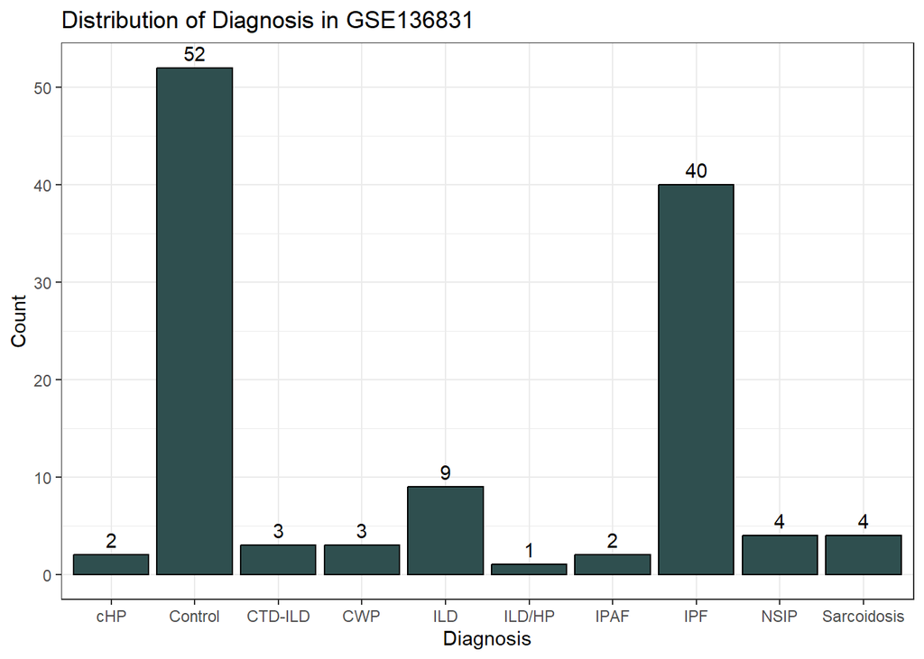

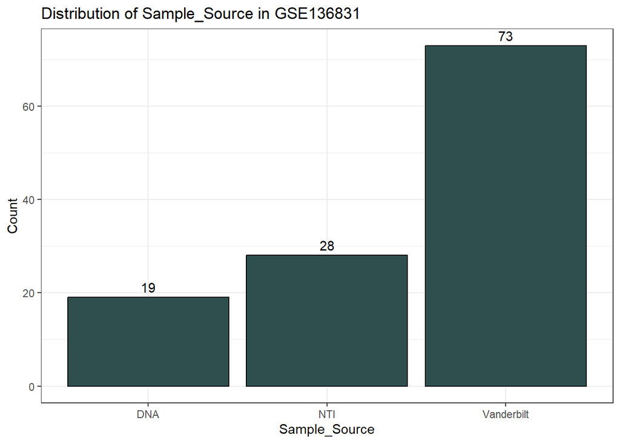

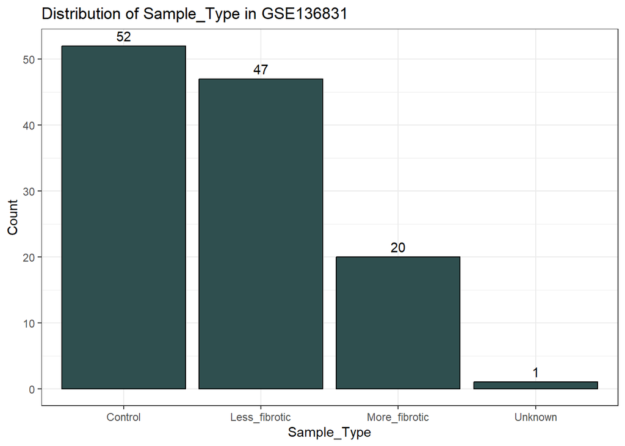

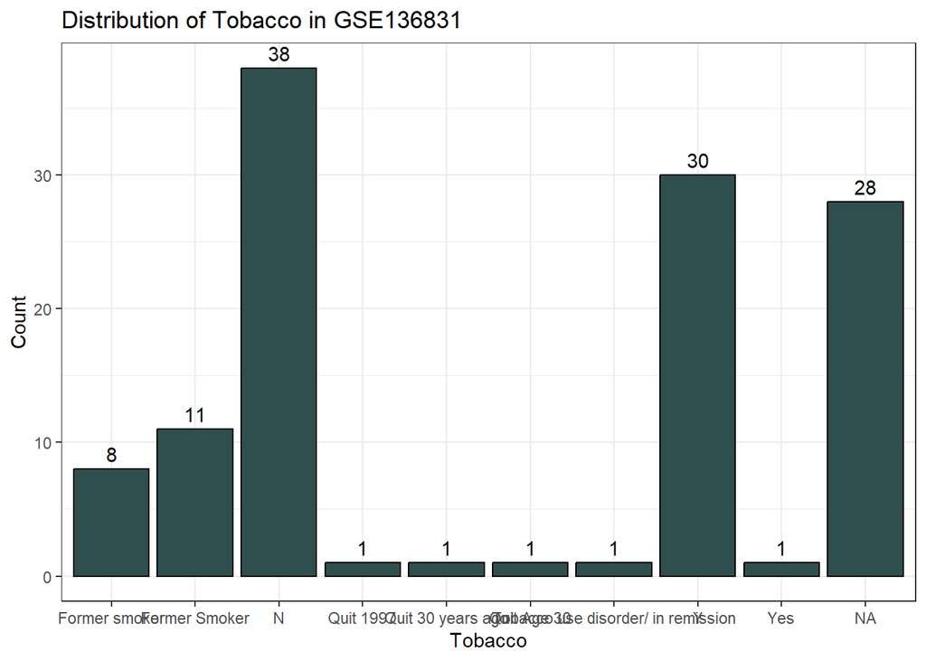

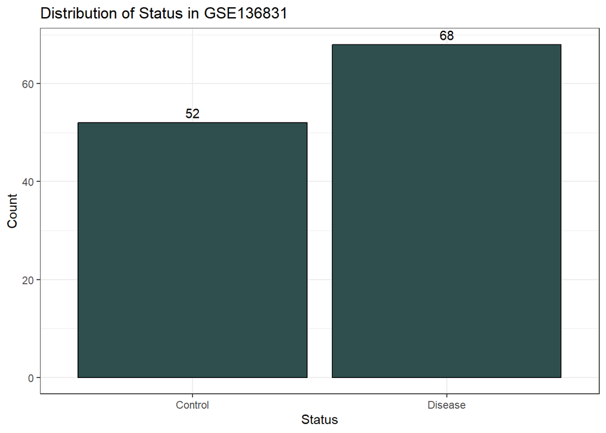

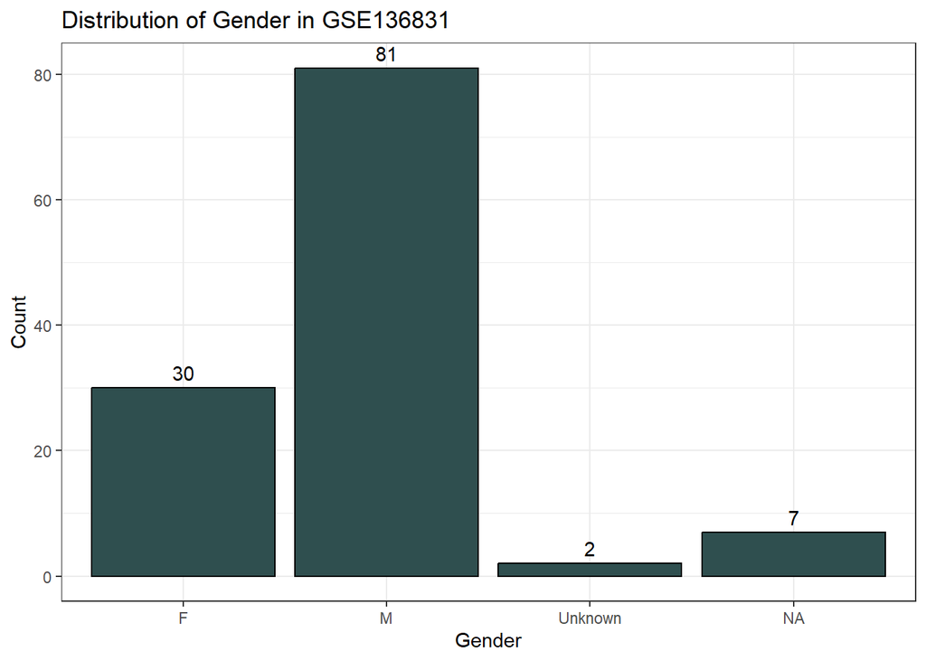

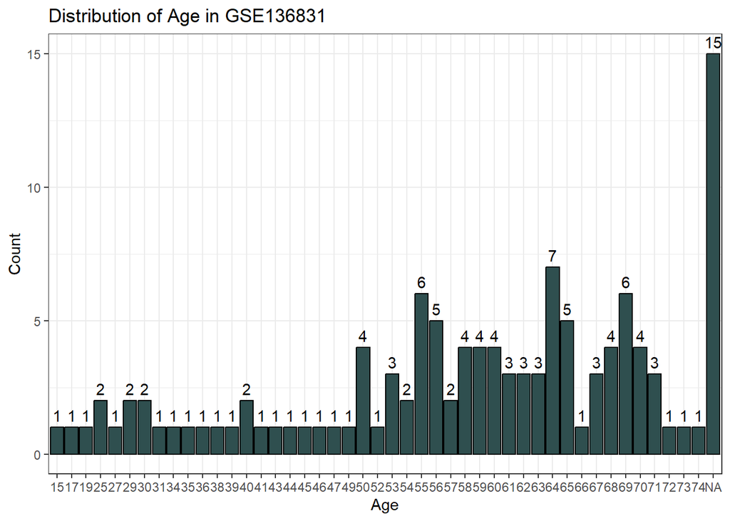

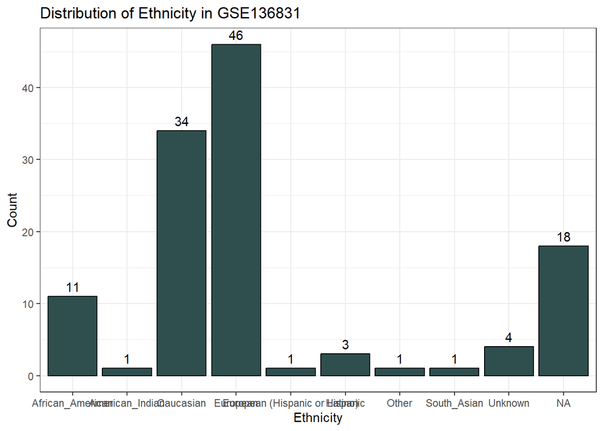

```r
# Calculate novelty score.
obj$log10GenesPerUMI <- log10(obj$nFeature_RNA) / log10(obj$nCount_RNA)

# Get sample level metadata.
metadata <- Extract_Sample_Meta(obj,
                                sample_col = "Sample_Name",
                                variables_include = c("Diagnosis", "Sample_Source", "Sample_Type", "Tobacco", "Status", "Gender", "Age", "Ethnicity"))

# Plot some preliminary sample-level data.
columns_incl <- colnames(metadata)
columns_incl <- columns_incl[columns_incl != "Sample_Name"]

for (col in columns_incl) {
  p <- ggplot(metadata, aes_string(x = col)) +
    geom_bar(fill = "darkslategrey", colour = "black") +
    geom_text(stat = "count", aes(label = after_stat(count)), vjust = -0.5) +
    labs(title = paste("Distribution of", col, "in GSE136831"),
         x = col,
         y = "Count") +
    theme_bw()

  print(p)
}
```

```r
# We are only interested in IPF and control, which represent the bulk of the diagnoses in this dataset, so let's subset to include those two only.
dim(obj) # 28,237; 475,047
```

```
## [1]  28237 475047
```

```r
subset_obj <- subset(obj, subset = Diagnosis %in% c("IPF", "Control"), invert = FALSE)
dim(subset_obj) # 28,237; 328,429
```

```
## [1]  28237 328429
```

```r
# Remove unneeded objects.
rm(col, columns_incl, metadata, obj, p)
```

## Step 2: Quality Control

### Step 2.1: Visualize cell counts

Check cell counts with number of unique barcodes detected to determine capture efficiency.

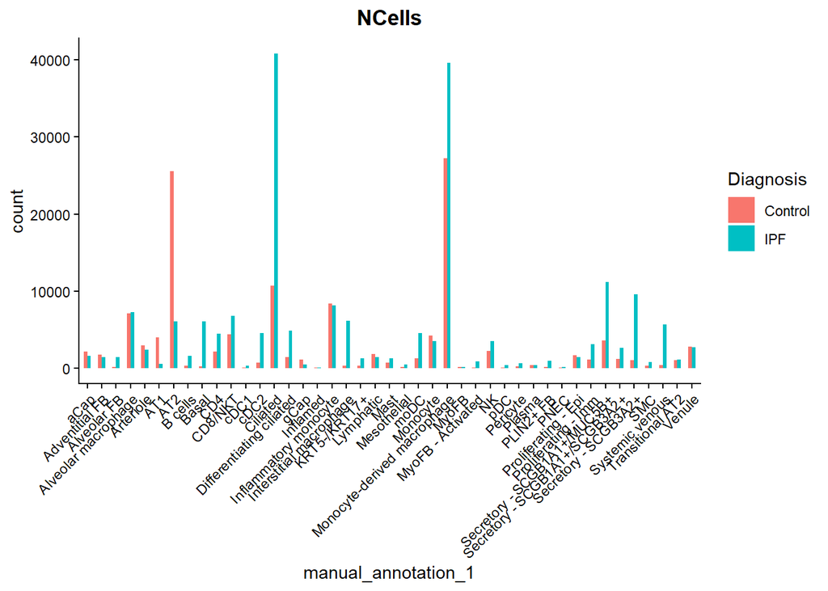

```r
# Get sample metadata from Seurat object.
meta <- subset_obj@meta.data

# Visualize cell counts.
meta %>%
  ggplot(aes(x = manual_annotation_1, fill = Diagnosis)) +
  geom_bar(width = 0.5, position = "dodge") +
  theme_classic() +
  theme(axis.text.x = element_text(angle = 45, vjust = 1, hjust = 1)) +
  theme(plot.title = element_text(hjust = 0.5, face = "bold")) +
  ggtitle("NCells")
```

### Step 2.2: Visualize UMI distribution across conditions

UMI counts should generally be above 500. If UMI counts are between 500 and 1000, the cells should probably be sequenced more deeply.

Note: Most are above 1000 so good sequencing depth.

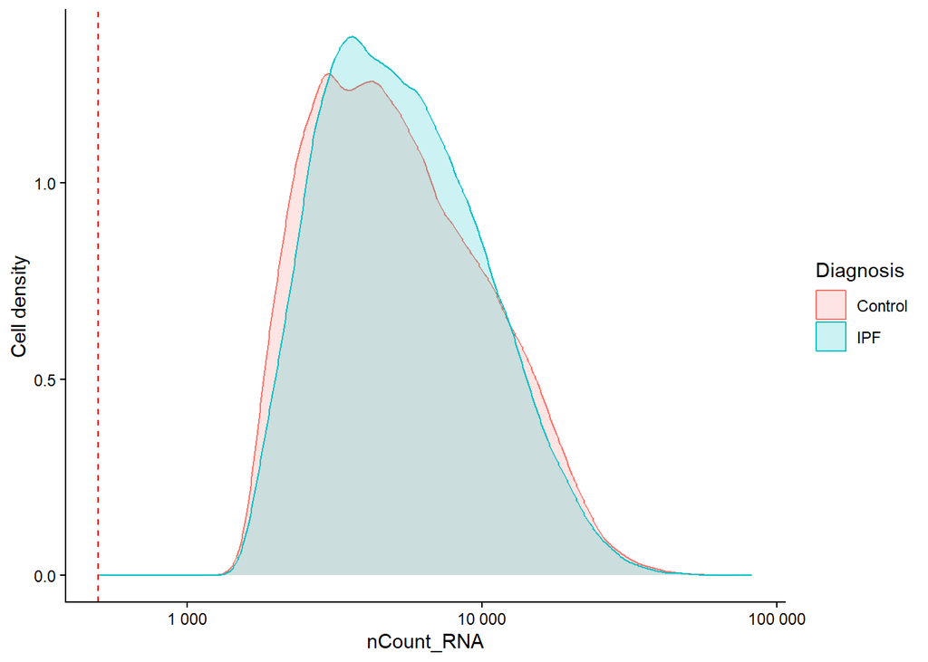

```r
# Visualize UMI counts per cell.
meta %>%
  ggplot(aes(x = nCount_RNA, color = Diagnosis, fill = Diagnosis)) +
  geom_density(alpha = 0.2) +
  scale_x_log10(labels = label_number()) +
  ylab("Cell density") +
  geom_vline(xintercept = 500, linetype = "dashed", color = "red") +
  theme_classic()
```

### Step 2.3: Visualize cell novelty score

Cells with novelty score above 0.80 are considered good quality cells.

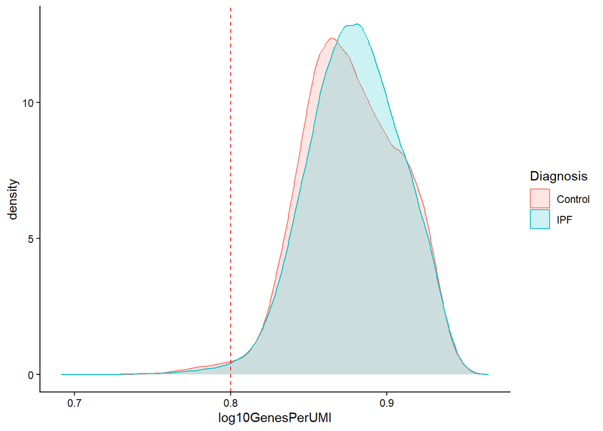

```r
# Visualize novelty score.
meta %>%
  ggplot(aes(x = log10GenesPerUMI, color = Diagnosis, fill = Diagnosis)) +
  geom_density(alpha = 0.2) +
  geom_vline(xintercept = 0.8, linetype = "dashed", color = "red") +
  theme_classic()
```

### Step 2.4: Visualize mito ratio

Low quality cells have mitochondrial ratio higher than 0.20.

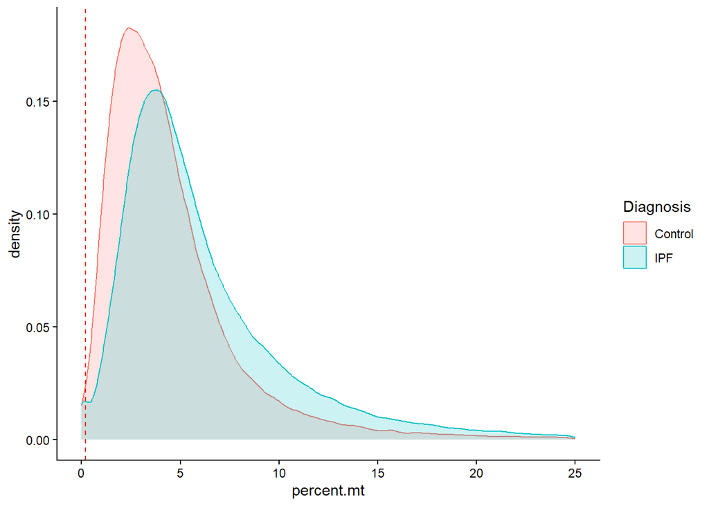

```r
# Visualize mitochondrial ratio.
meta %>%
  ggplot(aes(x = percent.mt, color = Diagnosis, fill = Diagnosis)) +
  geom_density(alpha = 0.2) +
  geom_vline(xintercept = 0.2, linetype = "dashed", color = "red") +
  theme_classic()
```

### Step 2.5: Visualize joint filtering effects

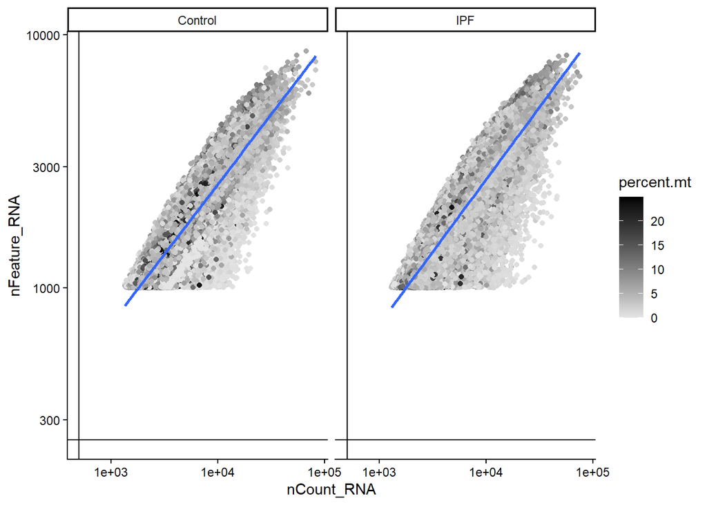

```r
# Visualize joint filtering QCs.
meta %>%
    ggplot(aes(x = nCount_RNA, y = nFeature_RNA, color = percent.mt)) +
    geom_point() +
    scale_colour_gradient(low = "gray90", high = "black") +
    stat_smooth(method = lm) +
    scale_x_log10() +
    scale_y_log10() +
    geom_vline(xintercept = 500) +
    geom_hline(yintercept = 250) +
    theme_classic() +
    facet_wrap(~Diagnosis)
```

### Step 2.6: Visualize valid cells with knee plot

A distinct “cliff-and-knee” shape indicates a healthy sample with clear separation between true cells and background “empty” droplets, while other shapes can point to issues with sample quality.

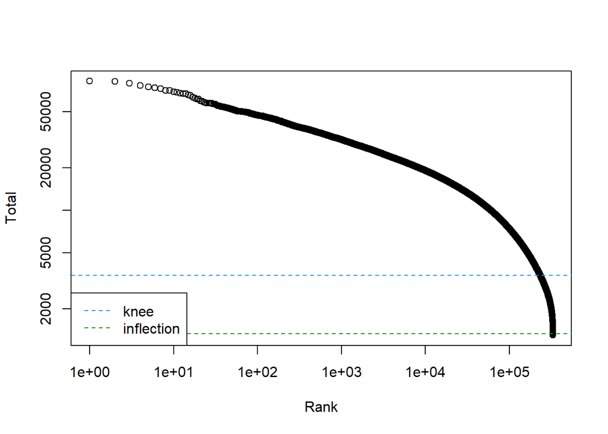

```r
# Rank expression barcodes.
br.out = barcodeRanks(subset_obj@assays$RNA$counts)

# Plot knee plot.
plot(br.out$rank, br.out$total, log = "xy", xlab = "Rank", ylab = "Total")
abline(h = metadata(br.out)$knee, col = "dodgerblue", lty = 2)
abline(h = metadata(br.out)$inflection, col = "forestgreen", lty = 2)
legend("bottomleft", lty = 2, col = c("dodgerblue", "forestgreen"), legend = c("knee", "inflection"))
```

```r
# Remove unneeded objects.
rm(br.out, meta)
```

All the QC checks look good. We are not going to do any cell-level or gene-level filtering since we have less than ideal number of cells available to us.

## Step 3: Normalization

### Step 3.1: Pre-normalization distribution

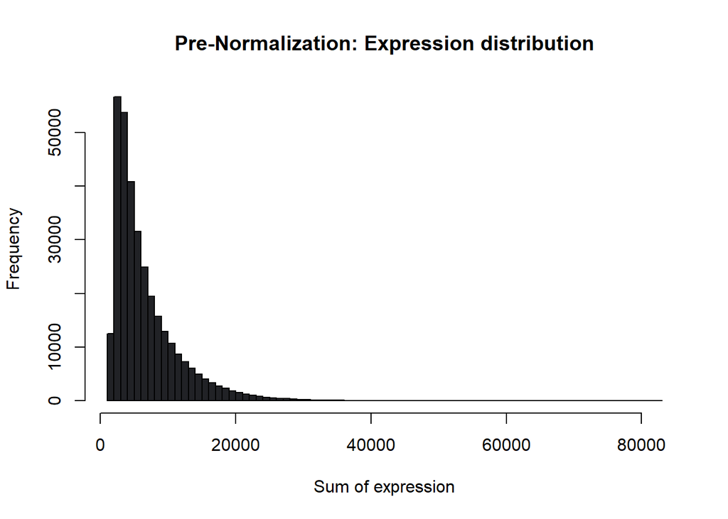

```r
# Visualize expression distribution before normalization.
hist(colSums(subset_obj[["RNA"]]$counts),
     breaks = 100,
     col = "#212226",
     main = "Pre-Normalization: Expression distribution",
     xlab = "Sum of expression")
```

### Step 3.2: Post-normalization distribution

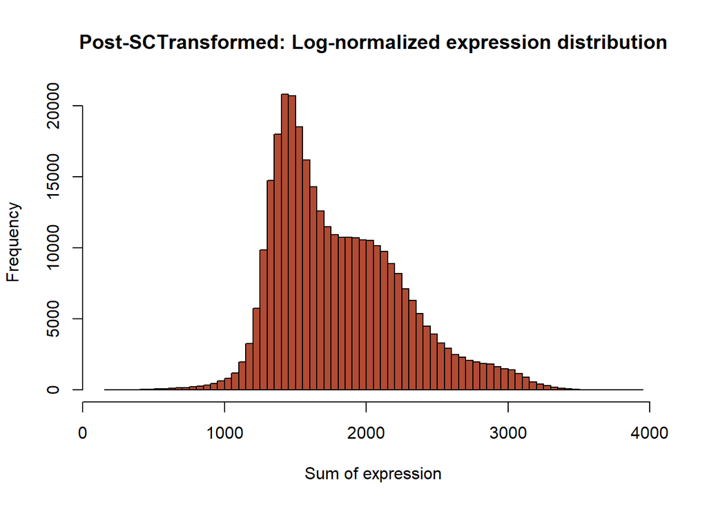

```r
# Visualize expression distribution after SCT.
hist(colSums(subset_obj[["SCT"]]$data),
     breaks = 100,
     col = "#b14b34",
     main = "Post-SCTransformed: Log-normalized expression distribution",
     xlab = "Sum of expression")
```

## Step 4: Dimensional Reduction and Clustering

### Step 4.1: Run PCA

```r
# Run PCA.
seurat_sct <- RunPCA(subset_obj, verbose = FALSE)

# Visualize PC dimensions with elbow plot.
# Determine percent of variation associated with each PC.
pct <- seurat_sct[["pca"]]@stdev / sum(seurat_sct[["pca"]]@stdev) * 100

# Calculate cumulative percents for each PC.
cumu <- cumsum(pct)

# Determine which PC exhibits cumulative percent greater than 90% and % variation associated with the PC as less than 5.
co1 <- which(cumu > 90 & pct < 5)[1]
co1
```

```
## [1] 41
```

```r
# Determine the difference between variation of PC and subsequent PC.
co2 <- sort(which((pct[1:length(pct) - 1] - pct[2:length(pct)]) > 0.1), decreasing = T)[1] + 1

# Last point where change of % of variation is more than 0.1%.
co2
```

```
## [1] 24
```

```r
# Minimum of the two calculation.
pcs <- min(co1, co2)
pcs
```

```
## [1] 24
```

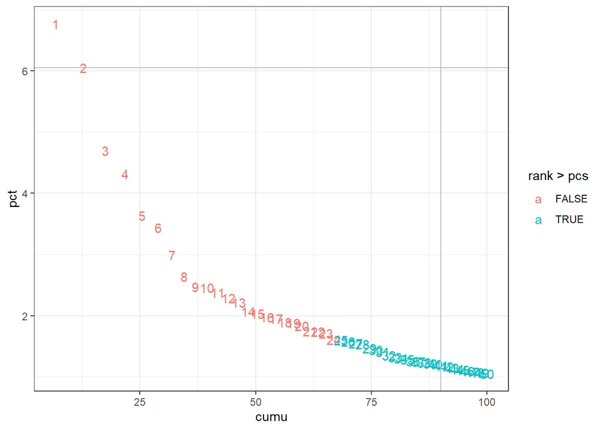

```r
# Create a dataframe with values.
elbowplot_df <- data.frame(pct = pct,
                           cumu = cumu,
                           rank = 1:length(pct))

# Elbow plot to visualize.
ggplot(elbowplot_df, aes(cumu, pct, label = rank, color = rank > pcs)) +
  geom_text() +
  geom_vline(xintercept = 90, color = "grey") +
  geom_hline(yintercept = min(pct[pct > 5]), color = "grey") +
  theme_bw()
```

```r
# Remove unneeded objects.
rm(co1, co2, cumu, elbowplot_df, pcs, pct)
```

### Step 4.2: Run UMAP

```r
# Visualize dimension reduction from PCA.
seurat_sct <- RunUMAP(seurat_sct, dims = 1:30, reduction = "pca")
```

```
## Rasterizing points since number of points exceeds 100,000.
## To disable this behavior set `raster=FALSE`
```

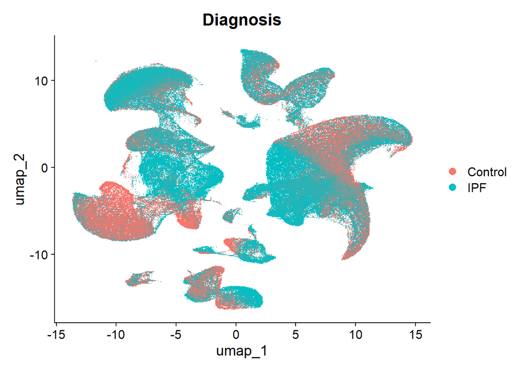

```r
DimPlot(object = seurat_sct, group.by = "Diagnosis")
```

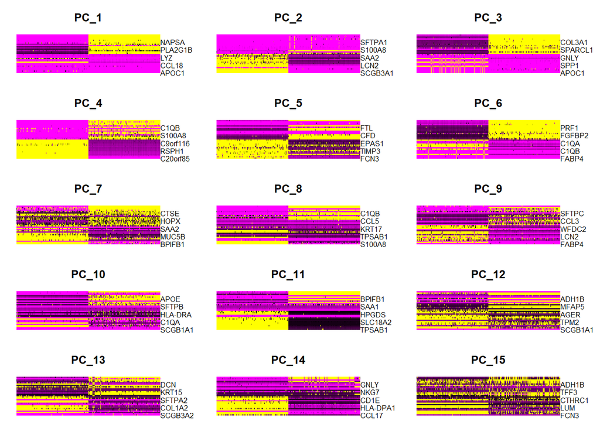

```r
# Explore the top PC markers.
DimHeatmap(seurat_sct,
           dims = 1:15,
           cells = 500,
           balanced = TRUE)
```

### Step 4.3: Compute KNN

```r
# Compute SNN graph.
seurat_cluster <- FindNeighbors(object = seurat_sct, dims = 1:30) # Based on elbow plot.
# Remove unneeded objects.
rm(seurat_sct)
```

### Step 4.4: Explore cluster resolutions

```r
# Determine start and end resolution range.
start_reso_range = 0.6
end_reso_range = 1.2
range_interval = 0.2

# Find clusters given the range.
seurat_cluster <- FindClusters(object = seurat_cluster,
                               resolution = seq(from = start_reso_range,
                                                to = end_reso_range,
                                                by = range_interval))
```

[output not shown]

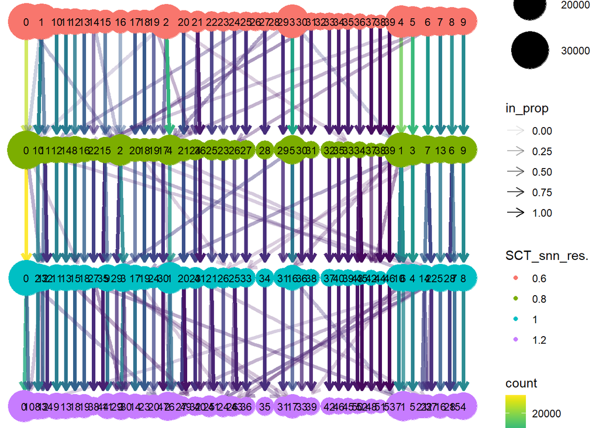

```r
# Remove unneeded objects.
rm(start_reso_range, end_reso_range, range_interval)

# Visualize relationship between different cluster resolutions using clustree.
clustree(seurat_cluster)
```

### Step 4.5: Choose cluster resolution

Note: Resolution at around 0.6 looks stable based on clustree above.

```
## Rasterizing points since number of points exceeds 100,000.
## To disable this behavior set `raster=FALSE`
```

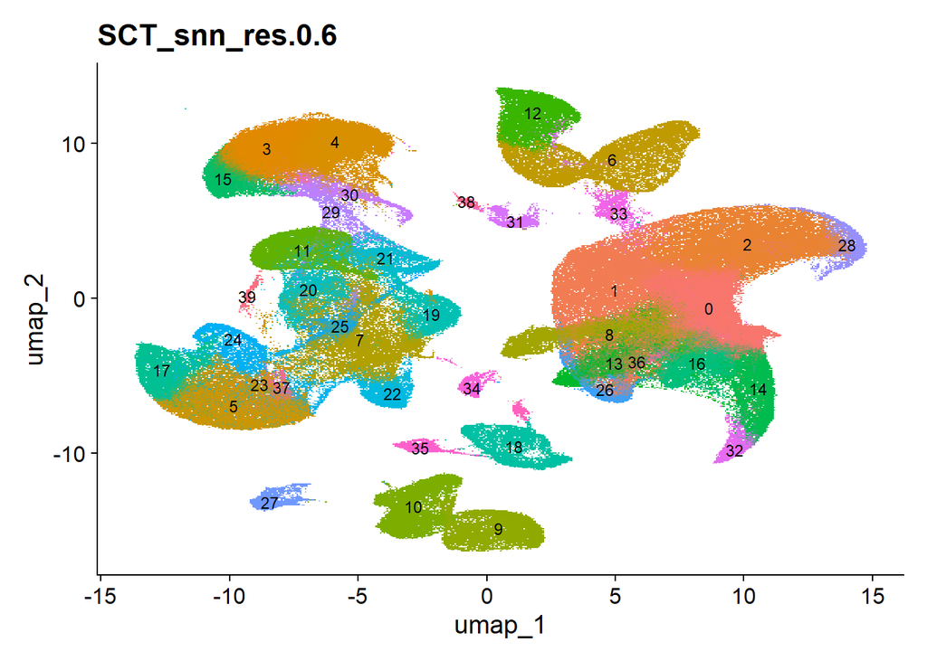

```r
# Assign desired cluster resolution as identity of Seurat.
Idents(object = seurat_cluster) <- "SCT_snn_res.0.6"

# Visualize cluster with a UMAP.
DimPlot(seurat_cluster,
        reduction = "umap",
        label = TRUE,
        label.size = 3) +
  ggtitle("SCT_snn_res.0.6") +
  NoLegend()
```

## Step 5: Cell Type Annotation

### Step 5.1: Find top markers associated with each cluster

```r
# Find markers for every cluster compared to all remaining cells. Include only positive markers.
cluster_markers <- FindAllMarkers(seurat_cluster, only.pos = TRUE)
datatable(
  cluster_markers %>%
    group_by(cluster) %>%
    dplyr::filter(avg_log2FC > 1) %>%
    slice_max(order_by = p_val_adj, n = 10, with_ties = FALSE) %>%
    arrange(cluster, p_val_adj),
  caption = "Top 10 highly differential markers by cluster",
  options = list(pageLength = 10, scrollX = TRUE),
  rownames = FALSE
) %>%
  formatRound(columns = c("avg_log2FC"), digits = 3) %>%
  formatSignif(columns = c("p_val"), digits = 3) %>%
  formatSignif(columns = c("p_val_adj"), digits = 3)
```

| p_val | avg_log2FC | pct.1 | pct.2 | p_val_adj | cluster | gene |
| --- | --- | --- | --- | --- | --- | --- |
| 6.372102620508384e-39 | 1.151676172707446 | 0.011 | 0.005 | 1.799290616952953e-34 | 0 | AC007728.2 |
| 3.322676348256414e-37 | 1.052037991898017 | 0.011 | 0.005 | 9.382241204571637e-33 | 0 | AC011611.3 |
| 1.229640398500219e-33 | 1.031577791023414 | 0.011 | 0.005 | 3.472135593245068e-29 | 0 | IL27 |
| 2.328631346783895e-32 | 1.01996560277377 | 0.012 | 0.006 | 6.575356333913685e-28 | 0 | CLEC6A |
| 6.558481149704045e-32 | 1.087963942021366 | 0.01 | 0.005 | 1.851918322241931e-27 | 0 | AC083949.1 |
| 1.402056755458615e-31 | 1.041863019960704 | 0.011 | 0.005 | 3.958987660388492e-27 | 0 | CABP4 |
| 1.433729019394722e-31 | 1.122098915787878 | 0.01 | 0.004 | 4.048420632064876e-27 | 0 | AL359182.2 |
| 2.846937207848552e-29 | 1.007946725417907 | 0.01 | 0.005 | 8.038896593801956e-25 | 0 | AC005264.1 |
| 5.0998485438372e-29 | 1.022874812088864 | 0.011 | 0.005 | 1.44004423332331e-24 | 0 | SYN1 |
| 2.103071496348927e-26 | 1.041383645139639 | 0.01 | 0.005 | 5.938442984240465e-22 | 0 | PIWIL4 |

[output cut: 390 more lines]

```r
# Remove unneeded objects.
rm(cluster_markers)
```

### Step 5.2: Visualize clusters against known markers

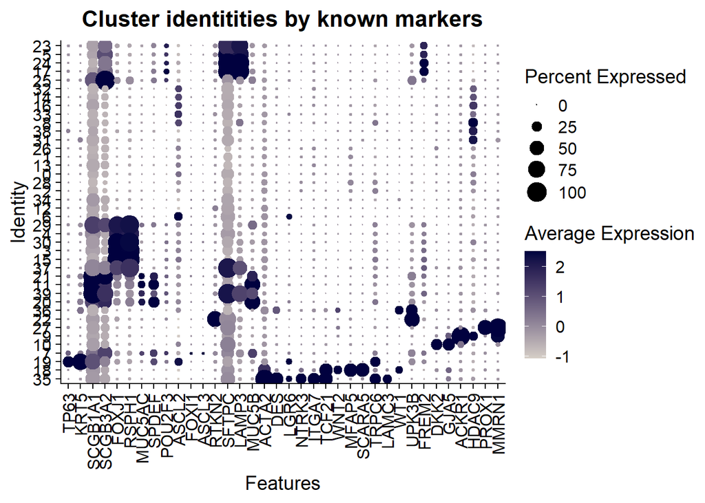

```r
# Visualize the clusters against [known markers of interest](https://pmc.ncbi.nlm.nih.gov/articles/PMC9202574/).
# Basal cells: TP63, KRT5
# Secretory cells: SCGB1A1, SCGB3A2
# Ciliated cells: FOXJ1, RSPH1
# Goblet cells: MUC5AC, SPDEF
# Tuft cells: POU2F3, ASCL2
# Ionocytes: FOXI1, ASCL3
# AT1: AGERH, RTKN2
# AT2: SFTPC, LAMP3
# Mucous cells: MUC5B, SPDEF
# Airway SMCs: ACTA2, DES, LGR6
# vSMCs: NTRK3, ITGA7
# Alveolar fibroblasts 1: TCF21, WNT2
# Alveolar fibroblasts 2: MFAP5, SCARA5
# Pericytes: TRPC6, LAMC3
# Mesothelium: WT1, UPK3B, FREM2
# Arterial endothelial cells: DKK2, GJA5
# Venous endothelial cells: ACKR1, HDAC9
# Lymphatic endothelial cells: PROX1, MMRN1
DotPlot(seurat_cluster,
        features = c("TP63", "KRT5",
                     "SCGB1A1", "SCGB3A2",
                     "FOXJ1", "RSPH1",
                     "MUC5AC", "SPDEF",
                     "POU2F3", "ASCL2",
                     "FOXI1", "ASCL3",
                     "RTKN2",
                     "SFTPC", "LAMP3",
                     "MUC5B",
                     "ACTA2", "DES", "LGR6",
                     "NTRK3", "ITGA7",
                     "TCF21", "WNT2",
                     "MFAP5", "SCARA5",
                     "TRPC6", "LAMC3",
                     "WT1", "UPK3B", "FREM2",
                     "DKK2", "GJA5",
                     "ACKR1", "HDAC9",
                     "PROX1", "MMRN1"),
        cluster.idents = TRUE,
        cols = c("#d6cfc7", "#01013f"),
        dot.scale = 6,
        scale.by = "size") +
  ggtitle("Cluster identitities by known markers") +
  theme(plot.title = element_text(hjust = 0.5),
        axis.text.x = element_text(angle = 90, vjust = 0.5, hjust = 1))
```

### Step 5.3: Run Azimuth annotation

Note: Prediction score is high across the board for all cell types.

```r
# Check all available Azimuth references.
available_data <- AvailableData()
available_data[grep("lung", available_data[, 3]), 1:3] # Use lungref.
```

```
##                    Dataset Version                 Summary
## lungref.SeuratData lungref   2.0.0 Azimuth Reference: lung
```

```r
# Run Azimuth with lungref.
options(future.globals.maxSize = 1000000000)
seurat_annotated <- RunAzimuth(seurat_cluster, reference = "lungref")
```

```
## detected inputs from HUMAN with id type Gene.name
```

```
## reference rownames detected HUMAN with id type Gene.name
```

```
## Normalizing query using reference SCT model
```

```
## Only one SCT model detected; no need to select.
```

```
## Projecting cell embeddings
```

```
## Finding query neighbors
```

```
## Finding neighborhoods
```

```
## Finding anchors
```

```
##  Found 251335 anchors
```

```
## Finding integration vectors
```

```
## Finding integration vector weights
```

```
## Predicting cell labels
## Predicting cell labels
## Predicting cell labels
## Predicting cell labels
## Predicting cell labels
## Predicting cell labels
```

```
##
## Integrating dataset 2 with reference dataset
```

```
## Finding integration vectors
```

```
## Integrating data
```

```
## Running UMAP projection
```

```
## 18:41:05 Processing block 1 of 1
```

```
## 18:42:43 Finished
```

```
## Projecting reference PCA onto query
## Finding integration vector weights
## Projecting back the query cells into original PCA space
## Finding integration vector weights
## Computing scores:
##     Finding neighbors of original query cells
##     Finding neighbors of transformed query cells
##     Computing query SNN
##     Determining bandwidth and computing transition probabilities
## Total elapsed time: 10.7844140529633
```

```
## Rasterizing points since number of points exceeds 100,000.
## To disable this behavior set `raster=FALSE`
```

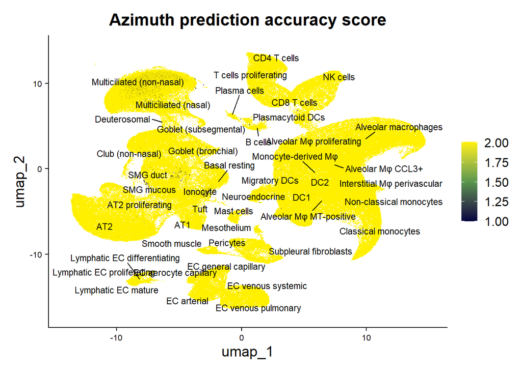

```r
# Check annotation accuracy.
Idents(seurat_annotated) <- "predicted.ann_finest_level"
FeaturePlot(
  seurat_annotated,
  features = "mapping.score",
  cols = c("#01013f", "#59974d", "#fff000"),
  label = TRUE,
  label.size = 3,
  repel = TRUE,
  label.color = "black"
) +
  theme(axis.text.x = element_text(size = 8),
        axis.text.y = element_text(size = 8)) +
  ggtitle("Azimuth prediction accuracy score")
```

```r
# Remove unneeded object.
rm(available_data, seurat_cluster)
```

### Step 5.4: Collapse similar cell type groups

```r
# Find unique identified cell types.
seurat_annotated$cell_type = seurat_annotated$predicted.ann_finest_level
unique(seurat_annotated$cell_type) %>% sort()
```

```
##  [1] "Adventitial fibroblasts"      "Alveolar fibroblasts"
##  [3] "Alveolar macrophages"         "Alveolar Mφ CCL3+"
##  [5] "Alveolar Mφ MT-positive"      "Alveolar Mφ proliferating"
##  [7] "AT1"                          "AT2"
##  [9] "AT2 proliferating"            "B cells"
## [11] "Basal resting"                "CD4 T cells"
## [13] "CD8 T cells"                  "Classical monocytes"
## [15] "Club (nasal)"                 "Club (non-nasal)"
## [17] "DC1"                          "DC2"
## [19] "Deuterosomal"                 "EC aerocyte capillary"
## [21] "EC arterial"                  "EC general capillary"
## [23] "EC venous pulmonary"          "EC venous systemic"
## [25] "Goblet (bronchial)"           "Goblet (nasal)"
## [27] "Goblet (subsegmental)"        "Interstitial Mφ perivascular"
## [29] "Ionocyte"                     "Lymphatic EC differentiating"
## [31] "Lymphatic EC mature"          "Lymphatic EC proliferating"
## [33] "Mast cells"                   "Mesothelium"
## [35] "Migratory DCs"                "Monocyte-derived Mφ"
## [37] "Multiciliated (nasal)"        "Multiciliated (non-nasal)"
## [39] "Myofibroblasts"               "Neuroendocrine"
## [41] "NK cells"                     "Non-classical monocytes"
## [43] "Peribronchial fibroblasts"    "Pericytes"
## [45] "Plasma cells"                 "Plasmacytoid DCs"
## [47] "SM activated stress response" "SMG duct"
## [49] "SMG mucous"                   "SMG serous (bronchial)"
## [51] "Smooth muscle"                "Subpleural fibroblasts"
## [53] "Suprabasal"                   "T cells proliferating"
## [55] "Transitional Club-AT2"        "Tuft"
```

```r
# Collapse all the endothelial cells.
grep("EC", seurat_annotated$cell_type, value = TRUE) %>% unique()
```

```
## [1] "EC general capillary"         "EC arterial"
## [3] "Lymphatic EC mature"          "EC venous systemic"
## [5] "Lymphatic EC differentiating" "EC venous pulmonary"
## [7] "EC aerocyte capillary"        "Lymphatic EC proliferating"
```

```r
seurat_annotated@meta.data <- mutate(seurat_annotated@meta.data,
                                     cell_type =
                                       recode(cell_type,
                                              "EC arterial" = "Endothelial",
                                              "EC venous pulmonary" = "Endothelial",
                                              "EC general capillary" = "Endothelial",
                                              "EC venous systemic" = "Endothelial",
                                              "EC aerocyte capillary" = "Endothelial",
                                              "Lymphatic EC mature" = "Lymphatic EC",
                                              "Lymphatic EC differentiating" = "Lymphatic EC",
                                              "Lymphatic EC proliferating" = "Lymphatic EC"))

# Collapse all the fibroblasts.
grep("fibroblast", seurat_annotated$cell_type, value = TRUE) %>% unique()
```

```
## [1] "Adventitial fibroblasts"   "Myofibroblasts"
## [3] "Peribronchial fibroblasts" "Subpleural fibroblasts"
## [5] "Alveolar fibroblasts"
```

```r
seurat_annotated@meta.data <- mutate(seurat_annotated@meta.data,
                                     cell_type =
                                       recode(cell_type,
                                              "Adventitial fibroblasts" = "Fibroblasts",
                                              "Alveolar fibroblasts" = "Fibroblasts",
                                              "Peribronchial fibroblasts" = "Fibroblasts",
                                              "Subpleural fibroblasts" = "Fibroblasts"))

# Collapse all the immune cells.
seurat_annotated$cell_type[seurat_annotated$predicted.ann_level_1 == "Immune"] %>% unique()
```

```
##  [1] "Plasma cells"                 "Interstitial Mφ perivascular"
##  [3] "B cells"                      "Monocyte-derived Mφ"
##  [5] "CD4 T cells"                  "Alveolar macrophages"
##  [7] "NK cells"                     "Mast cells"
##  [9] "Plasmacytoid DCs"             "AT1"
## [11] "Non-classical monocytes"      "Alveolar Mφ MT-positive"
## [13] "Multiciliated (non-nasal)"    "Classical monocytes"
## [15] "CD8 T cells"                  "Endothelial"
## [17] "Migratory DCs"                "DC2"
## [19] "T cells proliferating"        "Alveolar Mφ CCL3+"
## [21] "DC1"                          "Alveolar Mφ proliferating"
## [23] "Transitional Club-AT2"        "AT2 proliferating"
## [25] "AT2"                          "Goblet (nasal)"
```

```r
seurat_annotated@meta.data <- mutate(seurat_annotated@meta.data,
                                     cell_type =
                                       recode(cell_type,
                                              "Plasma cells" = "Immune",
                                              "Interstitial Mφ perivascular" = "Immune",
                                              "B cells" = "Immune",
                                              "Monocyte-derived Mφ" = "Immune",
                                              "CD4 T cells" = "Immune",
                                              "Alveolar macrophages" = "Immune",
                                              "NK cells" = "Immune",
                                              "Mast cells" = "Immune",
                                              "Plasmacytoid DCs" = "Immune",
                                              "Non-classical monocytes" = "Immune",
                                              "Alveolar Mφ MT-positive" = "Immune",
                                              "Classical monocytes" = "Immune",
                                              "CD8 T cells" = "Immune",
                                              "Migratory DCs" = "Immune",
                                              "DC2" = "Immune",
                                              "T cells proliferating" = "Immune",
                                              "Alveolar Mφ CCL3+" = "Immune",
                                              "DC1" = "Immune",
                                              "Alveolar Mφ proliferating" = "Immune"))
```

### Step 5.5: Visualize finalized cell type annotation

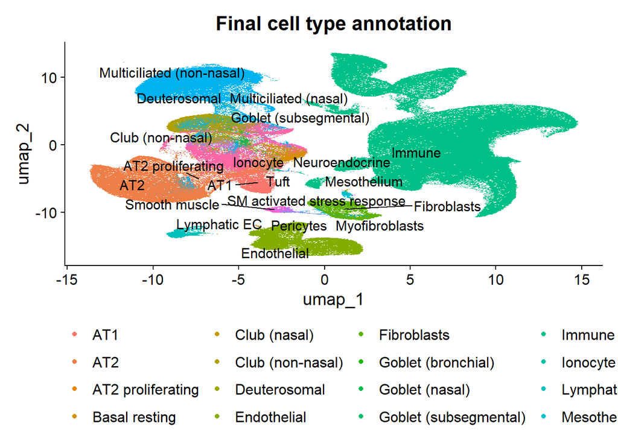

```r
 # Visualize finalized annotation with a UMAP.
DimPlot(seurat_annotated,
        reduction = "umap",
        group.by = "cell_type",
        label = TRUE,
        label.size = 4,
        repel = TRUE) +
  ggtitle("Final cell type annotation") +
  theme(plot.title = element_text(hjust = 0.5),
        legend.position = "bottom",
        legend.spacing.x = unit(0.2, "cm"),
        legend.spacing.y = unit(0.1, "cm")) +
  guides(colour = guide_legend(nrow = 4))
```

## Step 6: Save Seurat Object

```r
# Save Seurat object.
saveRDS(object = seurat_annotated,
        file = "Z:/Kendrix/IPF_Lung/GSE135893/processed_data/preprocessed_seurat_obj.rds")
```